# ASSIGNMENT - A4(1)

# **Performing Principal Component Analysis and Factor Analysis to identify data dimensions**

- **AUTHOR** : Rakshitha Vignesh Sargurunathan
- **VID** : V01109007
- **CREATED ON** : 07/07/2024

# Principal Component Analysis (PCA) :

- The main goal of Principal Component Analysis (PCA) is to reduce the dimensionality of a dataset while preserving the most important patterns or relationships between the variables without any prior knowledge of the target variables.
- Principal Component Analysis (PCA) is a statistical procedure that uses an orthogonal transformation that converts a set of correlated variables to a set of uncorrelated variables.PCA is the most widely used tool in exploratory data analysis and in machine learning for predictive models.
- Principal Component Analysis (PCA) is an unsupervised learning algorithm technique used to examine the interrelations among a set of variables. It is also known as a general factor analysis where regression determines a line of best fit.

PROBLEM STATEMENT :

Perform Principal Component Analysis to identify data dimensions on Survey dataset

```python
import pandas as pd
import numpy as np
import matplotlib.pyplot as plt
import seaborn as sns
```

```python
data = pd.read_csv("/content/drive/MyDrive/SCMA/A4 - PCA,MDS,FA,CA,CA/Survey.csv")
```

### Basic EDA to explore the dataset

```python
data.head()
```

|  | City | Sex | Age | Occupation | Monthly Household Income | Income | Planning to Buy a new house | Time Frame | Reasons for buying a house | what type of House | ... | 4. Availability of domestic help | Time | Size | Budgets | Maintainances | EMI.1 | ages | sex | Finished/Semi Finished.1 | Influence Decision.1 |
| --- | --- | --- | --- | --- | --- | --- | --- | --- | --- | --- | --- | --- | --- | --- | --- | --- | --- | --- | --- | --- | --- |
| 0 | Bangalore | M | 26-35 | Private Sector | 85,001 to105,000 | 95000 | Yes | 6M to 1Yr | Residing | Apartment | ... | 1 | 9 | 1200 | 72.5 | 30000 | 42500 | 30.5 | M | Semifurnished | Site visits |
| 1 | Bangalore | M | 46-60 | Government/PSU | 45,001 to 65,000 | 55000 | Yes | 6M to 1Yr | Investment | Apartment | ... | 2 | 9 | 800 | 32.5 | 120 | 27500 | 53.0 | M | Semifurnished | Newspaper |
| 2 | Bangalore | F | 46-60 | Government/PSU | 25,001 to 45,000 | 35000 | Yes | <6 Months | Rental Income | Apartment | ... | 4 | 3 | 400 | 12.5 | 10000 | 10000 | 53.0 | F | Semifurnished | Hoarding |
| 3 | Bangalore | M | 36-45 | Private Sector | >125000 | 200000 | Yes | <6 Months | Investment | Apartment | ... | 5 | 3 | 1600 | 102.5 | 70000 | 80000 | 40.5 | M | Furnished | Electronic/Internet |
| 4 | Bangalore | M | 26-35 | Self Employed | 85,001 to105,000 | 95000 | Yes | 1-2 Yr | Residing | Apartment | ... | 3 | 18 | 800 | 52.5 | 30000 | 42500 | 30.5 | M | Semifurnished | Electronic/Internet |

5 rows × 50 columns

```python
data.columns
```

```
Index(['City', 'Sex', 'Age', 'Occupation', 'Monthly Household Income',
       'Income', 'Planning to Buy a new house', 'Time Frame',
       'Reasons for buying a house', 'what type of House', 'Number of rooms',
       'Size of House', 'Budget', 'Finished/Semi Finished',
       'Influence Decision', 'Maintainance', 'EMI', '1.Proximity to city',
       '2.Proximity to schools', '3. Proximity to transport',
       '4. Proximity to work place', '5. Proximity to shopping',
       '1. Gym/Pool/Sports facility', '2. Parking space', '3.Power back-up',
       '4.Water supply', '5.Security', '1. Exterior look ', '2. Unit size',
       '3. Interior design and branded components',
       '4. Layout plan (Integrated etc.)', '5. View from apartment',
       '1. Price', '2. Booking amount', '3. Equated Monthly Instalment (EMI)',
       '4. Maintenance charges', '5. Availability of loan',
       '1. Builder reputation', '2. Appreciation potential',
       '3. Profile of neighbourhood', '4. Availability of domestic help',
       'Time', 'Size', 'Budgets', 'Maintainances', 'EMI.1', 'ages', 'sex',
       'Finished/Semi Finished.1', 'Influence Decision.1'],
      dtype='object')
```

```python
data.shape
```

```
(70, 50)
```

```python
data.info()
```

```
<class 'pandas.core.frame.DataFrame'>
RangeIndex: 70 entries, 0 to 69
Data columns (total 50 columns):
 #   Column                                     Non-Null Count  Dtype
---  ------                                     --------------  -----
 0   City                                       70 non-null     object
 1   Sex                                        70 non-null     object
 2   Age                                        70 non-null     object
 3   Occupation                                 70 non-null     object
 4   Monthly Household Income                   70 non-null     object
 5   Income                                     70 non-null     int64
 6   Planning to Buy a new house                70 non-null     object
 7   Time Frame                                 70 non-null     object
 8   Reasons for buying a house                 70 non-null     object
 9   what type of House                         70 non-null     object
```

[output cut: 42 more lines]

```python
data.describe()
```

|  | Income | 1.Proximity to city | 2.Proximity to schools | 3. Proximity to transport | 4. Proximity to work place | 5. Proximity to shopping | 1. Gym/Pool/Sports facility | 2. Parking space | 3.Power back-up | 4.Water supply | ... | 1. Builder reputation | 2. Appreciation potential | 3. Profile of neighbourhood | 4. Availability of domestic help | Time | Size | Budgets | Maintainances | EMI.1 | ages |
| --- | --- | --- | --- | --- | --- | --- | --- | --- | --- | --- | --- | --- | --- | --- | --- | --- | --- | --- | --- | --- | --- |
| count | 70.000000 | 70.000000 | 70.000000 | 70.000000 | 70.000000 | 70.000000 | 70.000000 | 70.000000 | 70.000000 | 70.000000 | ... | 70.000000 | 70.000000 | 70.000000 | 70.000000 | 70.000000 | 70.000000 | 70.000000 | 70.000000 | 70.000000 | 70.000000 |
| mean | 99000.000000 | 3.628571 | 3.442857 | 4.071429 | 3.842857 | 2.628571 | 3.242857 | 3.528571 | 3.500000 | 3.914286 | ... | 4.328571 | 4.171429 | 3.842857 | 3.142857 | 7.328571 | 1120.000000 | 64.142857 | 38001.714286 | 46107.142857 | 44.328571 |
| std | 59670.593345 | 0.870972 | 1.016326 | 0.728736 | 0.942333 | 0.783367 | 1.134897 | 0.696189 | 0.607919 | 0.675511 | ... | 0.756066 | 0.613175 | 0.714969 | 0.982244 | 4.994842 | 627.301559 | 40.769069 | 26185.208291 | 22468.317929 | 12.956417 |
| min | 35000.000000 | 1.000000 | 2.000000 | 3.000000 | 2.000000 | 1.000000 | 1.000000 | 2.000000 | 2.000000 | 2.000000 | ... | 2.000000 | 3.000000 | 2.000000 | 1.000000 | 3.000000 | 300.000000 | 12.500000 | 120.000000 | 10000.000000 | 21.500000 |
| 25% | 55000.000000 | 3.000000 | 3.000000 | 4.000000 | 3.000000 | 2.000000 | 3.000000 | 3.000000 | 3.000000 | 4.000000 | ... | 4.000000 | 4.000000 | 3.000000 | 2.000000 | 3.000000 | 800.000000 | 32.500000 | 15000.000000 | 27500.000000 | 30.500000 |
| 50% | 75000.000000 | 4.000000 | 3.000000 | 4.000000 | 4.000000 | 3.000000 | 3.000000 | 3.500000 | 3.500000 | 4.000000 | ... | 4.000000 | 4.000000 | 4.000000 | 3.000000 | 9.000000 | 800.000000 | 52.500000 | 30000.000000 | 42500.000000 | 40.500000 |
| 75% | 115000.000000 | 4.000000 | 4.000000 | 5.000000 | 5.000000 | 3.000000 | 4.000000 | 4.000000 | 4.000000 | 4.000000 | ... | 5.000000 | 5.000000 | 4.000000 | 4.000000 | 9.000000 | 1600.000000 | 87.500000 | 50000.000000 | 57500.000000 | 53.000000 |
| max | 200000.000000 | 5.000000 | 5.000000 | 5.000000 | 5.000000 | 4.000000 | 5.000000 | 5.000000 | 5.000000 | 5.000000 | ... | 5.000000 | 5.000000 | 5.000000 | 5.000000 | 18.000000 | 4000.000000 | 150.000000 | 120000.000000 | 80000.000000 | 70.000000 |

8 rows × 31 columns

```python
data.isna().sum()
```

```
City                                         0
Sex                                          0
Age                                          0
Occupation                                   0
Monthly Household Income                     0
Income                                       0
Planning to Buy a new house                  0
Time Frame                                   0
Reasons for buying a house                   0
what type of House                           0
Number of rooms                              0
Size of House                                0
Budget                                       0
Finished/Semi Finished                       0
Influence Decision                           0
Maintainance                                 0
EMI                                          0
1.Proximity to city                          0
2.Proximity to schools                       0
3. Proximity to transport                    0
4. Proximity to work place                   0
5. Proximity to shopping                     0
1. Gym/Pool/Sports facility                  0
2. Parking space                             0
3.Power back-up                              0
4.Water supply                               0
5.Security                                   0
1. Exterior look                             0
2. Unit size                                 0
3. Interior design and branded components    0
4. Layout plan (Integrated etc.)             0
5. View from apartment                       0
1. Price                                     0
2. Booking amount                            0
3. Equated Monthly Instalment (EMI)          0
4. Maintenance charges                       0
5. Availability of loan                      0
1. Builder reputation                        0
2. Appreciation potential                    0
3. Profile of neighbourhood                  0
4. Availability of domestic help             0
Time                                         0
Size                                         0
Budgets                                      0
Maintainances                                0
EMI.1                                        0
ages                                         0
sex                                          0
Finished/Semi Finished.1                     0
Influence Decision.1                         0
dtype: int64
```

### Standardizing the dataset

```python
# Select numeric columns
numeric_columns = data.select_dtypes(include=['int64', 'float64']).columns
print("\nTHE NUMERICAL COLUMNS ARE \n\n:",numeric_columns)
```

```
THE NUMERICAL COLUMNS ARE

: Index(['Income', '1.Proximity to city', '2.Proximity to schools',
       '3. Proximity to transport', '4. Proximity to work place',
       '5. Proximity to shopping', '1. Gym/Pool/Sports facility',
       '2. Parking space', '3.Power back-up', '4.Water supply', '5.Security',
       '1. Exterior look ', '2. Unit size',
       '3. Interior design and branded components',
       '4. Layout plan (Integrated etc.)', '5. View from apartment',
       '1. Price', '2. Booking amount', '3. Equated Monthly Instalment (EMI)',
       '4. Maintenance charges', '5. Availability of loan',
       '1. Builder reputation', '2. Appreciation potential',
       '3. Profile of neighbourhood', '4. Availability of domestic help',
       'Time', 'Size', 'Budgets', 'Maintainances', 'EMI.1', 'ages'],
      dtype='object')
```

```python
numeric_data = data[numeric_columns]
print("\nTHE NUMERICAL DATA IS \n\n:")
numeric_data.head()
```

```
THE NUMERICAL DATA IS

:
```

|  | Income | 1.Proximity to city | 2.Proximity to schools | 3. Proximity to transport | 4. Proximity to work place | 5. Proximity to shopping | 1. Gym/Pool/Sports facility | 2. Parking space | 3.Power back-up | 4.Water supply | ... | 1. Builder reputation | 2. Appreciation potential | 3. Profile of neighbourhood | 4. Availability of domestic help | Time | Size | Budgets | Maintainances | EMI.1 | ages |
| --- | --- | --- | --- | --- | --- | --- | --- | --- | --- | --- | --- | --- | --- | --- | --- | --- | --- | --- | --- | --- | --- |
| 0 | 95000 | 3 | 5 | 5 | 2 | 1 | 2 | 5 | 3 | 5 | ... | 4 | 5 | 4 | 1 | 9 | 1200 | 72.5 | 30000 | 42500 | 30.5 |
| 1 | 55000 | 3 | 5 | 5 | 3 | 1 | 1 | 4 | 2 | 4 | ... | 5 | 4 | 3 | 2 | 9 | 800 | 32.5 | 120 | 27500 | 53.0 |
| 2 | 35000 | 1 | 2 | 5 | 2 | 1 | 4 | 3 | 2 | 4 | ... | 4 | 4 | 4 | 4 | 3 | 400 | 12.5 | 10000 | 10000 | 53.0 |
| 3 | 200000 | 4 | 5 | 3 | 5 | 4 | 5 | 5 | 4 | 5 | ... | 5 | 4 | 5 | 5 | 3 | 1600 | 102.5 | 70000 | 80000 | 40.5 |
| 4 | 95000 | 4 | 2 | 3 | 4 | 3 | 2 | 4 | 3 | 4 | ... | 4 | 3 | 4 | 3 | 18 | 800 | 52.5 | 30000 | 42500 | 30.5 |

5 rows × 31 columns

```python
# Standardize the data

from sklearn.preprocessing import StandardScaler
scaler = StandardScaler()
scaled_data = scaler.fit_transform(numeric_data)
scaled_data = pd.DataFrame(scaled_data, columns=numeric_columns)
scaled_data.head()
```

|  | Income | 1.Proximity to city | 2.Proximity to schools | 3. Proximity to transport | 4. Proximity to work place | 5. Proximity to shopping | 1. Gym/Pool/Sports facility | 2. Parking space | 3.Power back-up | 4.Water supply | ... | 1. Builder reputation | 2. Appreciation potential | 3. Profile of neighbourhood | 4. Availability of domestic help | Time | Size | Budgets | Maintainances | EMI.1 | ages |
| --- | --- | --- | --- | --- | --- | --- | --- | --- | --- | --- | --- | --- | --- | --- | --- | --- | --- | --- | --- | --- | --- |
| 0 | -0.067519 | -0.726900 | 1.543191 | 1.283423 | -1.969753 | -2.093947 | -1.103035 | 2.128808 | -0.828417 | 1.618854 | ... | -0.437718 | 1.361037 | 0.221377 | -2.197345 | 0.337047 | 0.128451 | 0.206467 | -0.307788 | -0.161703 | -1.075021 |
| 1 | -0.742706 | -0.726900 | 1.543191 | 1.283423 | -0.900895 | -2.093947 | -1.990534 | 0.682045 | -2.485251 | 0.127804 | ... | 0.894468 | -0.281594 | -1.187385 | -1.171917 | 0.337047 | -0.513805 | -0.781753 | -1.457129 | -0.834130 | 0.674109 |
| 2 | -1.080299 | -3.039766 | -1.429929 | 1.283423 | -1.969753 | -2.093947 | 0.671964 | -0.764717 | -2.485251 | 0.127804 | ... | -0.437718 | -0.281594 | 0.221377 | 0.878938 | -0.872865 | -1.156061 | -1.275863 | -1.077093 | -1.618628 | 0.674109 |
| 3 | 1.704847 | 0.429532 | 1.543191 | -1.480872 | 1.236821 | 1.763324 | 1.559463 | 2.128808 | 0.828417 | 1.618854 | ... | 0.894468 | -0.281594 | 1.630138 | 1.904366 | -0.872865 | 0.770707 | 0.947632 | 1.230822 | 1.519365 | -0.297630 |
| 4 | -0.067519 | 0.429532 | -1.429929 | -1.480872 | 0.167963 | 0.477567 | -1.103035 | 0.682045 | -0.828417 | 0.127804 | ... | -0.437718 | -1.924225 | 0.221377 | -0.146490 | 2.151916 | -0.513805 | -0.287643 | -0.307788 | -0.161703 | -1.075021 |

5 rows × 31 columns

### Checking for any independent variables

```python
R = scaled_data.corr()
np.round(R,2).head()
```

|  | Income | 1.Proximity to city | 2.Proximity to schools | 3. Proximity to transport | 4. Proximity to work place | 5. Proximity to shopping | 1. Gym/Pool/Sports facility | 2. Parking space | 3.Power back-up | 4.Water supply | ... | 1. Builder reputation | 2. Appreciation potential | 3. Profile of neighbourhood | 4. Availability of domestic help | Time | Size | Budgets | Maintainances | EMI.1 | ages |
| --- | --- | --- | --- | --- | --- | --- | --- | --- | --- | --- | --- | --- | --- | --- | --- | --- | --- | --- | --- | --- | --- |
| Income | 1.00 | 0.39 | 0.27 | -0.01 | 0.04 | 0.45 | 0.43 | 0.41 | 0.26 | 0.57 | ... | 0.52 | 0.25 | 0.60 | 0.56 | 0.11 | 0.83 | 0.89 | 0.85 | 0.81 | 0.53 |
| 1.Proximity to city | 0.39 | 1.00 | 0.27 | -0.25 | 0.46 | 0.28 | 0.28 | 0.30 | 0.25 | -0.01 | ... | 0.23 | 0.28 | 0.18 | 0.11 | 0.04 | 0.49 | 0.50 | 0.46 | 0.59 | 0.19 |
| 2.Proximity to schools | 0.27 | 0.27 | 1.00 | -0.04 | 0.36 | 0.26 | 0.35 | 0.30 | 0.27 | 0.37 | ... | 0.30 | 0.09 | 0.26 | 0.11 | -0.08 | 0.34 | 0.33 | 0.33 | 0.33 | 0.15 |
| 3. Proximity to transport | -0.01 | -0.25 | -0.04 | 1.00 | -0.11 | -0.16 | -0.00 | -0.10 | -0.11 | 0.34 | ... | 0.09 | 0.00 | 0.05 | -0.10 | 0.16 | -0.08 | -0.05 | -0.01 | -0.16 | -0.01 |
| 4. Proximity to work place | 0.04 | 0.46 | 0.36 | -0.11 | 1.00 | 0.14 | 0.20 | 0.08 | 0.39 | 0.16 | ... | 0.13 | -0.05 | 0.01 | -0.16 | 0.01 | 0.09 | 0.07 | 0.18 | 0.20 | -0.18 |

5 rows × 31 columns

```python
upper_tri = R.where(np.triu(np.ones(R.shape), k=1).astype(bool))

# Convert to long format and drop NaNs
correlation_pairs = upper_tri.stack().reset_index()
correlation_pairs.columns = ['Feature 1', 'Feature 2', 'Correlation']

# Sort the pairs by absolute correlation values in descending order
sorted_pairs = correlation_pairs.reindex(correlation_pairs['Correlation'].abs().sort_values(ascending=False).index)

# Display the sorted pairs
print(sorted_pairs)
```

```
                      Feature 1                    Feature 2   Correlation
459                     Budgets                Maintainances  9.292770e-01
456                        Size                Maintainances  8.935641e-01
455                        Size                      Budgets  8.920797e-01
26                       Income                      Budgets  8.892375e-01
460                     Budgets                        EMI.1  8.825102e-01
..                          ...                          ...           ...
453                        Time                        EMI.1  3.168526e-03
279           1. Exterior look                      1. Price  3.047353e-03
126  4. Proximity to work place            2. Booking amount  2.986383e-03
402      4. Maintenance charges  3. Profile of neighbourhood  1.531195e-03
222             3.Power back-up       4. Maintenance charges  6.344132e-18

[465 rows x 3 columns]
```

Budgets and Maintainances have the highest positive correlation coefficient of 0.93, indicating a strong positive linear relationship between them.This suggests that property with higher budget also tend to have higher Maintainances, and vice versa. Therefore, these two variables are dependent on each other.

Similarly there are other variables which are dependent to eachother

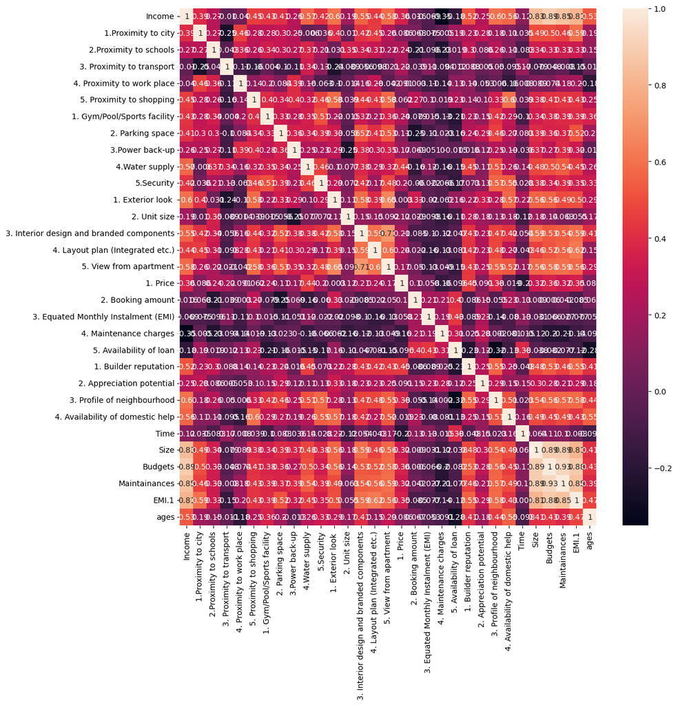

```python
fig, ax = plt.subplots(figsize=(12,12))
ax = sns.heatmap(np.round(R,3), annot=True)
plt.show()
```

From the output of above two cells we can say that there are dependent variables

```python
cov_matrix=np.cov(scaled_data.T)
cov_matrix
```

```
array([[ 1.01449275e+00,  3.95779276e-01,  2.69352105e-01,
        -1.01435655e-02,  4.02676018e-02,  4.60484530e-01,
         4.33571804e-01,  4.20110058e-01,  2.61428946e-01,
         5.74132327e-01,  4.25935672e-01,  6.04674550e-01,
         1.91037422e-01,  5.61306361e-01,  4.47902985e-01,
         5.84790071e-01,  3.65002688e-01,  1.65065989e-02,
        -7.03018967e-02, -3.55360211e-01, -1.81079815e-01,
         5.27300741e-01,  2.55973247e-01,  6.07926540e-01,
         5.68183105e-01,  1.16321915e-01,  8.47017646e-01,
         9.02124951e-01,  8.61047214e-01,  8.18678335e-01,
         5.37873396e-01],
       [ 3.95779276e-01,  1.01449275e+00,  2.74297784e-01,
        -2.58120284e-01,  4.64227086e-01,  2.87527239e-01,
         2.87288213e-01,  3.08983554e-01,  2.49915191e-01,
        -5.71196325e-03,  3.65977688e-02,  4.05147844e-01,
         1.01065952e-02,  4.24506509e-01,  4.53763544e-01,
         2.60583619e-01,  8.71305298e-02,  6.88357402e-02,
        -7.56182803e-02, -5.10061073e-03,  1.93712477e-01,
         2.35393451e-01,  2.87888539e-01,  1.86861761e-01,
         1.15392110e-01,  3.56313480e-02,  5.01070692e-01,
         5.06278967e-01,  4.69273508e-01,  5.98265632e-01,
         1.88976206e-01],
       [ 2.69352105e-01,  2.74297784e-01,  1.01449275e+00,
        -4.39572192e-02,  3.66471853e-01,  2.68038270e-01,
         3.50180034e-01,  3.03680653e-01,  2.73664817e-01,
         3.78141962e-01,  2.18564928e-01,  3.16558297e-02,
         3.59437965e-01,  3.44742938e-01,  3.15525365e-01,
         2.21016832e-01,  2.42674809e-01, -2.13490849e-01,
        -9.72050966e-02, -2.36040714e-01,  1.94264483e-02,
         3.02591424e-01,  8.69568865e-02,  2.60439254e-01,
         1.11512900e-01, -8.45308505e-02,  3.45463460e-01,
         3.35883965e-01,  3.38216383e-01,  3.35247707e-01,
         1.49969854e-01],
       [-1.01435655e-02, -2.58120284e-01, -4.39572192e-02,
         1.01449275e+00, -1.11640071e-01, -1.58210251e-01,
        -3.80948636e-03, -1.05571025e-01, -1.16158833e-01,
         3.41341786e-01,  1.33273344e-01, -2.44226204e-01,
        -9.05941555e-02, -5.64140561e-02, -9.93413206e-02,
         2.13684291e-02,  2.23894210e-01, -3.91767802e-02,
         1.16025308e-01, -9.52524717e-02,  1.23149823e-02,
```

[output cut: 286 more lines]

```
         5.60012748e-01,  2.95308891e-01,  5.90045569e-01,
         4.32321467e-01,  3.21444681e-03,  8.16745893e-01,
         8.95300183e-01,  8.63487586e-01,  1.01449275e+00,
         4.76944139e-01],
       [ 5.37873396e-01,  1.88976206e-01,  1.49969854e-01,
        -1.11228682e-02, -1.87120590e-01,  2.54291928e-01,
         3.66879151e-01,  1.99418949e-01, -1.30667458e-02,
         2.60336076e-01,  3.33974803e-01,  2.95454560e-01,
         1.70358994e-01,  4.13577306e-01,  1.56097332e-01,
         2.98619837e-01,  8.68329014e-02,  6.76475890e-02,
        -5.33288927e-02, -9.22988574e-02, -2.78725673e-01,
         4.15666933e-01,  1.82397422e-01,  4.50148772e-01,
         5.56525515e-01, -9.96367093e-02,  4.10624922e-01,
         4.32540904e-01,  3.92938401e-01,  4.76944139e-01,
         1.01449275e+00]])
```

```python
from numpy import linalg as LA  #We are taking transpose to ensure that the variables are represented as columns and observations as rows in the resulting matrix.

lambdas, eig_vector = LA.eig(np.array(cov_matrix))
print(lambdas)
print(eig_vector)
```

```
[10.1682947   2.73081517  2.25185268  1.90998419  1.7704195   1.44975581
  1.37662583  1.2470392   1.11010436  0.85902813  0.77087896  0.75253938
  0.62129649  0.60291877  0.549761    0.50232012  0.46385358  0.39664608
  0.30392755  0.29788997  0.0249316   0.04373722  0.05163295  0.05878212
  0.07026729  0.09653986  0.13935415  0.22604385  0.20974538  0.19520664
  0.19708281]
[[ 2.78240736e-01  3.85506925e-02  8.51663094e-02 -3.20642578e-02
   1.22423071e-01 -2.22481539e-01  4.91131670e-02  9.02236156e-02
  -8.55545693e-02  5.36582544e-02 -4.46244483e-02  7.22041807e-02
   4.64852943e-02  6.40821439e-02  5.06173085e-02  2.15530147e-02
  -8.63227934e-04 -2.14142527e-01  4.28795904e-02  3.92702384e-02
  -1.79075413e-02 -1.47502970e-01  1.98181317e-02  7.98094742e-01
   2.17474142e-01 -1.04242489e-02 -1.10564003e-01 -1.31216455e-01
   7.93045966e-02  1.29340486e-01 -5.05042857e-02]
 [ 1.60111868e-01 -1.77140064e-01 -3.55730555e-01  7.53265619e-02
   1.75151833e-01  3.58013687e-02  5.82847218e-02  8.82999169e-02
  -2.05342170e-01 -2.12774706e-01 -2.21027401e-01 -1.75267370e-01
  -2.43806621e-01 -8.56409038e-02 -2.85131879e-02 -1.47672610e-01
   7.99674161e-02 -7.95517030e-02  9.16419876e-03 -2.45880820e-01
   1.25050489e-02 -1.00189138e-01  1.44242164e-01 -4.20492398e-02
   1.12447486e-01 -1.43841316e-01 -6.58851731e-02 -1.60164841e-01
  -2.44015823e-01 -8.66962939e-02  5.24200093e-01]
 [ 1.38364078e-01  1.54984574e-01 -2.67502475e-01 -8.12929905e-02
  -3.89926854e-02  4.32239487e-02 -3.22601665e-01 -3.45230275e-01
  -2.07245598e-01  5.06875256e-02  1.35890312e-01  8.36430262e-02
   1.62293238e-02 -2.60638634e-01  1.69698093e-01  2.92559736e-02
  -4.28207813e-01  3.05712892e-01  1.08845923e-02 -6.27877035e-03
  -6.62282046e-02  1.19159860e-02 -8.07639912e-02  1.70511661e-01
  -2.26917588e-02  1.37804560e-01  3.36766739e-02  1.87009318e-01
   1.73294750e-01 -8.58767520e-02  2.70314751e-01]
 [-1.74669705e-02  1.58016993e-01  1.93985812e-01 -4.46450199e-01
  -1.32652357e-01 -1.03687840e-01  1.24345660e-01 -1.33065914e-01
   1.86665072e-01 -2.05444809e-01 -2.66162042e-01 -2.44267520e-01
  -5.62084236e-02 -4.31096554e-01 -2.67213250e-01  3.70721554e-02
  -1.89729713e-01 -2.01829155e-01 -5.13837935e-02 -2.33973487e-01
  -3.81912312e-02  3.85185998e-02 -1.13560955e-01  2.28701919e-02
  -2.79879459e-02  1.56502217e-01  1.02737194e-01 -1.36994105e-01
  -2.37804926e-03 -8.56544678e-03 -4.20076659e-02]
 [ 5.24890162e-02  5.49276547e-03 -5.29403076e-01 -9.23938930e-02
  -9.36332018e-02 -5.78948748e-02 -1.56325509e-01 -4.56143079e-02
```

[output cut: 199 more lines]

```
   1.30710392e-01 -1.61276794e-02  1.42588560e-01  1.64164981e-01
  -9.94565168e-02  3.29844784e-02  9.17744077e-02 -5.74137008e-02
  -8.30912851e-02  6.73664144e-02 -4.84571680e-02 -1.30035239e-01
  -6.91030997e-02 -2.73099634e-02  4.22916882e-02 -5.89651469e-03
  -2.32240574e-02 -5.51007005e-01 -2.21076002e-01 -1.59824189e-01
  -5.43320782e-02  4.29421344e-01  3.34115141e-01  2.16835730e-01
  -1.22525197e-01  1.45723547e-01 -1.60911017e-01]
 [ 1.66694563e-01  7.91313520e-02  2.75334986e-01  1.25283995e-01
   1.42153571e-01  4.86468184e-02 -1.32402781e-01  1.58409785e-01
  -2.53347420e-01 -3.08590541e-01  1.33348977e-03 -2.87377264e-01
   3.40569877e-01 -2.19370717e-01  1.19421200e-01 -2.89483980e-01
  -7.60790344e-02  9.89823396e-02 -5.23670726e-02  2.25565843e-01
  -7.57513536e-03  1.66807786e-01  1.00918605e-01 -8.66182756e-04
  -2.24938982e-01 -1.63311511e-01  1.30476031e-01 -1.24570486e-02
  -1.38933943e-01  2.84719347e-01 -5.46142748e-02]]
```

```python
# Make a list of (eigenvalue, eigenvector) tuples
eig_pairs = [(np.abs(lambdas[i]), eig_vector[:,i]) for i in range(len(lambdas))]

# Sort the (eigenvalue, eigenvector) tuples from high to low
eig_pairs.sort(key=lambda x: x[0], reverse=True)

# Confirm that the list is correctly sorted by decreasing eigenvalues
print('Eigenvalues in descending order:')
for i in eig_pairs:
    print(i[0])
```

```
Eigenvalues in descending order:
10.168294701892309
2.730815166621889
2.2518526819769953
1.909984192653213
1.7704194985019546
1.4497558137340554
1.376625831496885
1.2470392032139683
1.1101043565236473
0.859028132833171
0.7708789607614532
0.7525393801504973
0.6212964908780075
0.6029187693658333
0.5497610042645343
0.5023201212107429
0.46385358148078926
0.3966460777383037
0.30392755081755674
0.2978899736530334
0.22604385314058703
0.20974537618371714
0.19708280866245495
0.19520663865921126
0.13935414908097737
0.09653985869118224
0.07026729359344655
0.05878212102333007
0.05163295422965367
0.043737217444287865
0.02493160184114471
```

Explained variance: It helps to choose the number of principal components we are going to use

```python
# Extract only the eigenvalues
eigenvalues = np.array([pair[0] for pair in eig_pairs])
print(eigenvalues)
```

```
[10.1682947   2.73081517  2.25185268  1.90998419  1.7704195   1.44975581
  1.37662583  1.2470392   1.11010436  0.85902813  0.77087896  0.75253938
  0.62129649  0.60291877  0.549761    0.50232012  0.46385358  0.39664608
  0.30392755  0.29788997  0.22604385  0.20974538  0.19708281  0.19520664
  0.13935415  0.09653986  0.07026729  0.05878212  0.05163295  0.04373722
  0.0249316 ]
```

```python
total = sum(lambdas)
var_exp = [(i / total)*100 for i in sorted(lambdas, reverse=True)]  #calculates the explained variance ratio for each principal component.
var_exp
```

```
[32.33236564196172,
 8.683237165756237,
 7.160268896608879,
 6.073221626408834,
 5.629444488324188,
 4.60982263353225,
 4.377289510289635,
 3.9652398627540926,
 3.5298249124484635,
 2.731471943110083,
 2.4511819489649898,
 2.392867153473931,
 1.975551053943895,
 1.9171149809328343,
 1.7480879859102703,
 1.5972390950940674,
 1.4749261346624176,
 1.2612248554812422,
 0.9664055763323233,
 0.9472077503253136,
 0.7187569523825117,
 0.66693230215099,
 0.6266688386041194,
 0.6207031367504875,
 0.44310766297637966,
 0.3069700575894735,
 0.22343056488238763,
 0.18691089173316935,
 0.16417851805742414,
 0.13907225823298908,
 0.0792756003243772]
```

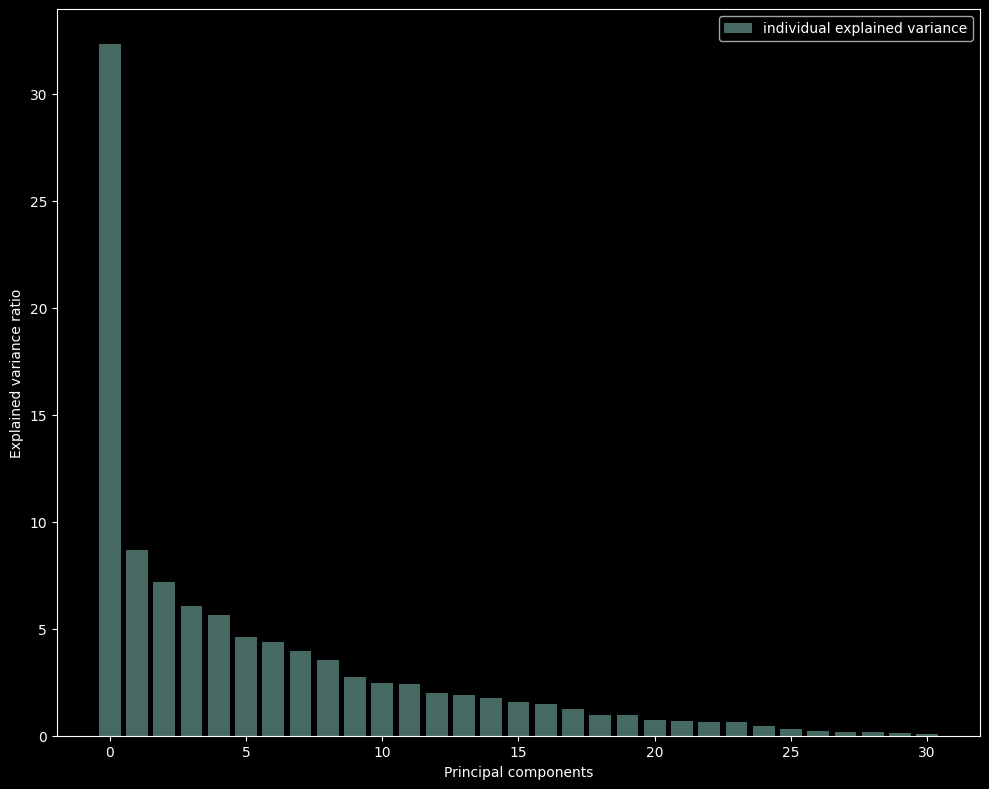

```python
with plt.style.context('dark_background'):
    plt.figure(figsize=(10, 8))

    plt.bar(range(31),var_exp, alpha=0.5, align='center',
            label='individual explained variance')
    plt.ylabel('Explained variance ratio')
    plt.xlabel('Principal components')
    plt.legend(loc='best')
    plt.tight_layout()
```

```
Number of components to reach 90% explained variance: 16
```

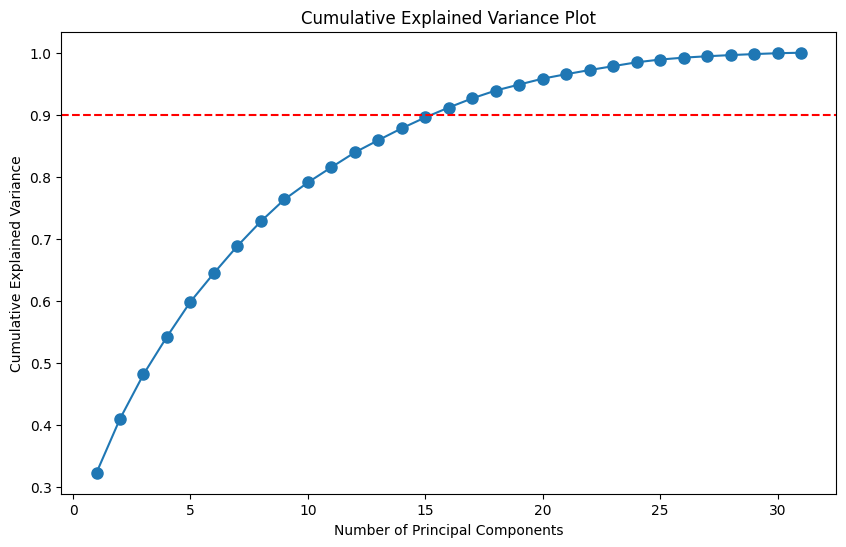

```python
# Calculate the explained variance ratio
explained_variance_ratio = eigenvalues / np.sum(eigenvalues)

# Calculate cumulative explained variance
cumulative_explained_variance = np.cumsum(explained_variance_ratio)


# Determine the number of components needed to reach 90% explained variance
n_components_90_variance = np.argmax(cumulative_explained_variance >= 0.90) + 1
print(f"\nNumber of components to reach 90% explained variance: {n_components_90_variance}\n\n")

# Plot cumulative explained variance
plt.figure(figsize=(10, 6))
plt.plot(range(1, len(cumulative_explained_variance) + 1), cumulative_explained_variance, 'o-', markersize=8)
plt.xlabel('Number of Principal Components')
plt.ylabel('Cumulative Explained Variance')
plt.title('Cumulative Explained Variance Plot')
plt.axhline(y=0.90, color='r', linestyle='--')  # Line for 90% explained variance
plt.show()
```

Cumulative Explained Variance:

- This method involves choosing the number of components that cumulatively explain a desired percentage of the total variance, commonly 90%.
- Based on our eigenvalues and the cumulative explained variance calculation, we need **16 components** to reach 90% of the total variance.

```python
# Perform PCA with 16 components (to reach 90% explained variance)

from sklearn.decomposition import PCA
pca = PCA(n_components=16)
pca_result = pca.fit_transform(scaled_data)
```

```python
# Create a DataFrame for the principal components
pca_df = pd.DataFrame(pca_result, columns=[f'PC{i+1}' for i in range(16)])
```

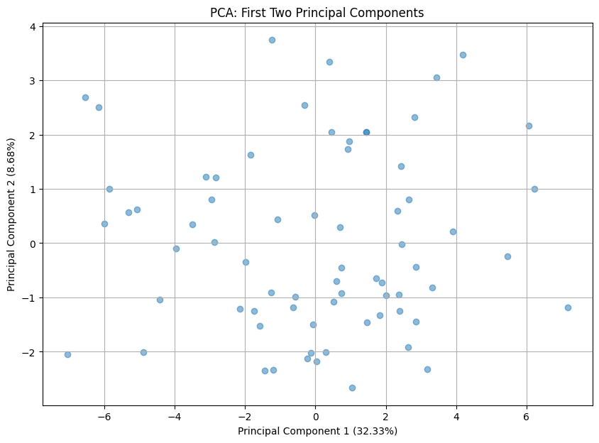

```python
# Plot the first two principal components
plt.figure(figsize=(10, 7))
plt.scatter(pca_df['PC1'], pca_df['PC2'], alpha=0.5)
plt.xlabel(f'Principal Component 1 ({pca.explained_variance_ratio_[0]*100:.2f}%)')
plt.ylabel(f'Principal Component 2 ({pca.explained_variance_ratio_[1]*100:.2f}%)')
plt.title('PCA: First Two Principal Components')
plt.grid(True)
plt.show()
```

```python
# Save the transformed data to a new CSV file

pca_df.to_csv('/content/drive/MyDrive/SCMA/A4 - PCA,MDS,FA,CA,CA/pca_transformed_data.csv', index=False)
```

# FACTOR ANALYSIS :

- Factor analysis is a statistical technique which is used to reduce the large number of variables into a fewer number of factors.
- For example, it is possible that variations in five observed variables mainly reflect the variation in one unobserved variable.
- The factor analysis technique extracts the maximum common variance from all the variables and puts them into a common score.

```python
! pip install pandas factor-analyzer
```

```
     ━━━━━━━━━━━━━━━━━━━━━━━━━━━━━━━━━━━━━━━━ 42.8/42.8 kB 1.8 MB/s eta 0:00:00
  Installing build dependencies ... done
  Getting requirements to build wheel ... done
  Preparing metadata (pyproject.toml) ... done
```

```python
from factor_analyzer import FactorAnalyzer

# Perform factor analysis
fa = FactorAnalyzer(n_factors=5, rotation='varimax')
fa.fit(numeric_data)
```

```
FactorAnalyzer(n_factors=5, rotation='varimax', rotation_kwargs={})
```

```python
# Check Eigenvalues to determine number of factors
ev, v = fa.get_eigenvalues()

# Display Eigenvalues
print("Eigenvalues:", ev)
```

```
Eigenvalues: [10.02303335  2.69180352  2.21968336  1.8826987   1.74512779  1.42904502
  1.35695975  1.22922436  1.09424572  0.8467563   0.7598664   0.74178882
  0.61242083  0.59430564  0.54190728  0.49514412  0.4572271   0.39097971
  0.29958573  0.2936344   0.22281466  0.20674901  0.19426734  0.19241797
  0.13736338  0.09516072  0.06926348  0.05794238  0.05089534  0.0431124
  0.02457544]
```

```python
# Get factor loadings
loadings = fa.loadings_

# Display factor loadings
print("Factor Loadings:\n", loadings)
```

```
Factor Loadings:
 [[ 0.81073141  0.42655805  0.0423175  -0.00886506  0.11372805]
 [ 0.45395509  0.09402697  0.52684104  0.11858559 -0.33385972]
 [ 0.23666143  0.19458277  0.43398609 -0.17475018  0.16885974]
 [-0.04180831 -0.04427952 -0.13373851  0.0571376   0.54372651]
 [ 0.00636878 -0.0419035   0.75504005 -0.05681202  0.00101822]
 [ 0.16646654  0.68221743  0.2033464   0.30658648 -0.08837542]
 [ 0.20519731  0.47219556  0.20892078 -0.12898696  0.16767277]
 [ 0.22540449  0.51947231  0.26644745 -0.12732138 -0.00368848]
 [ 0.04072361  0.42902807  0.48640409  0.04348195 -0.0193743 ]
 [ 0.35580103  0.36718373  0.17993394 -0.02810835  0.70032018]
 [ 0.10671187  0.72887151 -0.05534971 -0.0490653   0.27941198]
 [ 0.45784495  0.53565392 -0.02993563  0.35522209 -0.39441703]
 [ 0.26627538 -0.01175152 -0.09643742 -0.12515598 -0.00687646]
 [ 0.44255755  0.5570654   0.25992517 -0.03144779 -0.06322902]
 [ 0.4529768   0.34344889  0.38158042 -0.07069108 -0.10478155]
 [ 0.41582496  0.68496548  0.07819486  0.02926779 -0.06404502]
 [ 0.3593284   0.03736641  0.1678075  -0.07174366  0.42813897]
 [ 0.0377973   0.03600391 -0.1077053   0.52345043 -0.1468738 ]
 [-0.05837546 -0.07578014 -0.03919838  0.49509758  0.24595809]
 [-0.16668136 -0.03190028 -0.06577284  0.30383722 -0.0786587 ]
 [-0.12217684 -0.16821434  0.24469955  0.87062724 -0.04584381]
 [ 0.62875567  0.11296171  0.07553096 -0.15646963  0.20680684]
 [ 0.30082418  0.15364136  0.02455199  0.2518098  -0.00800247]
 [ 0.48026326  0.53587047  0.01339464 -0.17339895  0.24259195]
 [ 0.35030743  0.67994506 -0.26737366  0.10154747 -0.11127702]
 [ 0.03615116  0.07431415 -0.03337809  0.38530809  0.04812311]
 [ 0.79016575  0.35943896  0.1896176   0.07738986  0.0357845 ]
 [ 0.87837904  0.30343106  0.16837021  0.05278732  0.06302235]
 [ 0.76404362  0.38378523  0.25255865  0.05976172  0.11129394]
 [ 0.79026551  0.35884038  0.30923816 -0.05273559 -0.02723436]
 [ 0.46729368  0.34769994 -0.24553507 -0.12076971  0.01071324]]
```

```python
#Transform data
transformed_data = fa.transform(numeric_data)

# Display transformed data
print("Transformed Data:\n", transformed_data)
```

```
Transformed Data:
 [[ 3.52754123e-01 -8.87199237e-01  1.09867848e-01 -8.38559783e-01
   2.15528727e+00]
 [ 1.05090572e-01 -1.59891482e+00 -9.11853400e-01 -1.23376561e+00
   6.63568119e-01]
 [-8.37579138e-01 -1.21512102e-03 -3.03508756e+00 -1.54234236e+00
   1.40430135e+00]
 [ 4.59989264e-01  2.15473271e+00  8.52310211e-01 -2.11792537e+00
   2.24547101e-01]
 [-8.15437284e-01  7.05650155e-01  1.63889070e-01 -2.02066405e-01
  -9.07279726e-01]
 [-4.89157923e-01 -1.58854407e-01  1.83912792e-01 -1.24417936e-01
   5.17862178e-01]
 [ 7.45957076e-01  6.77735651e-01  6.32784621e-01  3.02580463e-01
   9.55150052e-01]
 [-2.78451110e-01 -2.17919092e+00 -1.12651659e+00 -1.41545249e+00
   2.06999812e-01]
 [ 2.65279812e-01 -1.17664809e+00 -1.65170635e-01  2.25474692e-01
   6.32783158e-02]
 [ 1.11982588e+00 -7.93674961e-01 -5.13625697e-02  4.95479293e-01
  -9.94302913e-01]
 [-1.09931557e+00  1.32555092e-01 -3.72679827e-01  2.94955118e-01
  -2.27137759e-01]
 [-1.06861335e-01 -1.13508689e+00  7.07825379e-01 -9.01607201e-01
  -1.35574386e+00]
 [-1.99844278e+00  2.73790443e-01  9.15657719e-01  6.65983946e-01
   1.10546327e+00]
 [ 2.05216915e-01 -2.13067046e-01  3.50260362e-01  8.26754149e-01
  -3.53220441e-02]
 [-5.55073239e-01 -6.78084734e-01 -4.94798878e-01  3.09783103e-02
   2.70666495e-01]
 [-1.41332600e+00 -1.85769767e+00 -2.68404876e-02 -1.04536485e-04
   2.44435372e-01]
 [-3.01161404e-01 -1.83940505e+00  7.08947754e-01 -2.06909578e-01
  -5.81153009e-01]
 [ 4.16740197e-02 -1.41555804e+00  1.08121333e+00 -5.18098514e-01
   8.93967839e-01]
 [ 1.07977635e+00 -4.71253765e-02  6.58547710e-01 -1.70175391e+00
   1.66149886e-01]
 [-4.33966631e-01  1.09682735e+00 -7.53805316e-02 -2.18808709e+00
```

[output cut: 86 more lines]

```
  -2.10723532e+00]
 [-9.59028280e-01  1.12076333e+00 -2.16649932e-01 -1.99208154e+00
   8.64636362e-01]
 [ 3.25487552e-03 -1.02579889e+00  8.96098584e-01 -1.92939868e-01
   1.63744983e-01]
 [-1.17939707e+00  3.90053325e-01 -5.92232202e-01  1.82395957e+00
   7.23081434e-01]
 [ 6.73884952e-01  5.55920531e-01 -1.38889779e+00  2.61062484e-01
  -1.57366922e+00]
 [-7.12124813e-01 -2.00338824e-01  2.38691395e-01 -3.22109014e-01
  -1.21228039e+00]
 [-7.88173159e-01  2.23444152e-03  1.25632747e+00 -5.39508469e-01
  -3.59991298e-01]
 [ 1.83942415e+00 -2.26841053e-01 -9.98363124e-01  7.20771458e-01
   1.25646269e+00]]
```